# HW 3

Brenda Onyango

9/9/2021

# HW 3: Probability Workshop

### Preparing for exercises.

First I loaded tidyverse.

```r
library(tidyverse)
```

Next I create the data frame of a deck of cards.

```r
deck <- tibble(
  card = rep(
    c("ace",
      "deuce",
      "three",
      "four",
      "five",
      "six",
      "seven",
      "eight",
      "nine",
      "ten",
      "jack",
      "queen",
      "king"
    ),4),
  suit =
    rep(c(
      "diamonds",
      "hearts",
      "clubs",
      "spades"),
        each = 13),
  color = rep(c("red",
                "black"),
              each = 26)) #dataframe of deck of cards
```

Next I viewed the deck of cards using glimpse.

```r
glimpse(deck) #deck has 52 cards and 3 variables.
```

```
## Rows: 52
## Columns: 3
## $ card  <chr> "ace", "deuce", "three", "four", "five", "six", "seven", "eight"…
## $ suit  <chr> "diamonds", "diamonds", "diamonds", "diamonds", "diamonds", "dia…
## $ color <chr> "red", "red", "red", "red", "red", "red", "red", "red", "red", "…
```

## Question 1

What is the probability of getting one black card first and then one red card in two draws with replacement? First I found the probability of drawing a black card.

```r
pr_black <- deck |> filter(color == "black") |> nrow()/nrow(deck)
```

Then I found the probability of drawing a red card.

```r
pr_red <-  deck |> filter(color == "red") |> nrow()/nrow(deck)
```

Then I multiplied the probabilities of each individual event.

```r
pr_black * pr_red
```

```
## [1] 0.25
```

The probabily of getting a black card and then a red card with replacement is 0.25.

### Question 2

For question 2, I first used ?sample_n in the console to understand the syntax for sample_n(). Then I repeated the chunk 5 times to generate 5 randomly sampled hands of 5 cards.

```r
sample_n(deck, 5, replace = FALSE) #sample 5 rows of the deck without replacement
```

```
## # A tibble: 5 × 3
##   card  suit     color
##   <chr> <chr>    <chr>
## 1 six   diamonds red
## 2 four  diamonds red
## 3 deuce diamonds red
## 4 ten   diamonds red
## 5 eight hearts   red
```

```r
sample_n(deck, 5, replace = FALSE) #2nd random hand
```

```
## # A tibble: 5 × 3
##   card  suit   color
##   <chr> <chr>  <chr>
## 1 queen spades black
## 2 three hearts red
## 3 nine  clubs  black
## 4 six   spades black
## 5 six   hearts red
```

```r
sample_n(deck, 5, replace = FALSE) #3rd random hand
```

```
## # A tibble: 5 × 3
##   card  suit     color
##   <chr> <chr>    <chr>
## 1 three diamonds red
## 2 deuce clubs    black
## 3 five  spades   black
## 4 nine  clubs    black
## 5 seven hearts   red
```

```r
sample_n(deck, 5, replace = FALSE) #4th random hand
```

```
## # A tibble: 5 × 3
##   card  suit     color
##   <chr> <chr>    <chr>
## 1 three diamonds red
## 2 jack  hearts   red
## 3 five  diamonds red
## 4 ten   diamonds red
## 5 three spades   black
```

```r
sample_n(deck, 5, replace = FALSE) #fifth random hand
```

```
## # A tibble: 5 × 3
##   card  suit     color
##   <chr> <chr>    <chr>
## 1 six   diamonds red
## 2 ace   spades   black
## 3 ace   diamonds red
## 4 eight spades   black
## 5 deuce spades   black
```

#### Question 2 part 2

What is the total number of *different* hands you could draw in poker? This question is asking from 52 cards, how many groups of 5 can I form. I will use a combination function to solve this.

```r
a <- choose(52, 5) # this function performed 52C5 = (52!)/(5!(52-5)!)
choose(52,5)
```

```
## [1] 2598960
```

### Question 3

What is the probability that each suit is represented in one hand (5 cards) of poker?

First I checked the deck and saw each of the four suits has 13 cards.I assume we’re drawing cards to form a hand of 5 without replacement. One suit will be drawn twice.

```r
s <- choose(4,1) #Choosing one suit out of 4 to be drawn twice
ss <- choose(13,2) #choosing 2 from one suit with 13 cards
```

Multiplying “s” and “2s” by 13 x 13 x 13 gives the number of hands with 1 card from each suit.

```r
s *ss * (13^3) #cubing 13 because 13 choose 1 is done 3 times for each of the other cards in the 5-card suit
```

```
## [1] 685464
```

To find the probability I will use the above as the numerator and the number of total possible hand outcomes as the denominator.

```r
(s*ss*(13^3))/a
```

```
## [1] 0.2637455
```

### Question 4

What is the probability of getting at least 1 ace in one 5-card hand? First I will find the probability of not getting aces. There are 4 aces in a 52-card deck. Without replacement the probability of drawing other cards 5 times is below.

```r
not_ace <- (48/52)*(47/51)*(46/50)*(45/49)*(44/48)
```

Subtracting the probability of not_ace from 1 will give the probability of at least one ace.

```r
1 - not_ace
```

```
## [1] 0.341158
```

Another way I could find this is by using a combination of 48 choose 5.

```r
no_ace <- choose(48,5) #number of possible hands with no aces
```

Then using object “a” (the number of possible 5-card hands) as the denominator to find probability of no aces.

```r
prob_noace <- (no_ace/a) #probability of hands with no aces
```

Then subtract this from 1 to find the probability of a hand with at least 1 ace.

```r
1 - prob_noace #complement rule to find probability of at least 1 ace
```

```
## [1] 0.341158
```

### Question 5

To prepare for this question I enter the info from stackoverflow.

```r
df <- tibble(
  id = 1:6,
  name = c("Alice", "Bob", "Charlie", "Diane", "Fred", "Jenny")
) #creating dataframe with 6 names for the committee
```

Then I using crossing (de-duplicates and sorts inputs) and unite (pastes multiple columns into one) to create a dataframe of possible pairs for the committee.

```r
df_pairs <- df |>
  rename(id1 = id, name1 = name) |>
  crossing(df |>
             select(id2 = id, name2 = name)) |>
  filter(id1 < id2) |>
  unite(id, id1, id2) |>
  unite(name, name1, name2)

df_pairs
```

```
## # A tibble: 15 × 2
##    id    name
##    <chr> <chr>
##  1 1_2   Alice_Bob
##  2 1_3   Alice_Charlie
##  3 1_4   Alice_Diane
##  4 1_5   Alice_Fred
##  5 1_6   Alice_Jenny
##  6 2_3   Bob_Charlie
##  7 2_4   Bob_Diane
##  8 2_5   Bob_Fred
##  9 2_6   Bob_Jenny
## 10 3_4   Charlie_Diane
## 11 3_5   Charlie_Fred
## 12 3_6   Charlie_Jenny
## 13 4_5   Diane_Fred
## 14 4_6   Diane_Jenny
## 15 5_6   Fred_Jenny
```

I could also find the number of combinations possible using choose().

```r
choose(6,2)
```

```
## [1] 15
```

### Question 6

Modify the code above so it shows all combinations when order does matter.

```r
df_orderpairs <- df |>
  rename(id1 = id, name1 = name) |>
  crossing(df |>
             select(id2 = id, name2 = name)) |>
  filter(id1 != id2) |> #changed filter from earlier code to find all pairs in which names don't equal each other to find all ordered pairs
  unite(id, id1, id2) |>
  unite(name, name1, name2)

df_orderpairs
```

```
## # A tibble: 30 × 2
##    id    name
##    <chr> <chr>
##  1 1_2   Alice_Bob
##  2 1_3   Alice_Charlie
##  3 1_4   Alice_Diane
##  4 1_5   Alice_Fred
##  5 1_6   Alice_Jenny
##  6 2_1   Bob_Alice
##  7 2_3   Bob_Charlie
##  8 2_4   Bob_Diane
##  9 2_5   Bob_Fred
## 10 2_6   Bob_Jenny
## # … with 20 more rows
```

Analytically I can perform a permutation.

```r
factorial(6)/factorial(4) #the denominator is correcting for counting pairs with same name e.g. Fred_Fred and equals (6 - 2)!
```

```
## [1] 30
```

### Question 7

1. 1000 draws of a fair die with a plot. First I will create a die object.

```r
die <- 1:6
```

Next I will roll the die 1000 times using the sample() function and set.seed() to save the rolls.

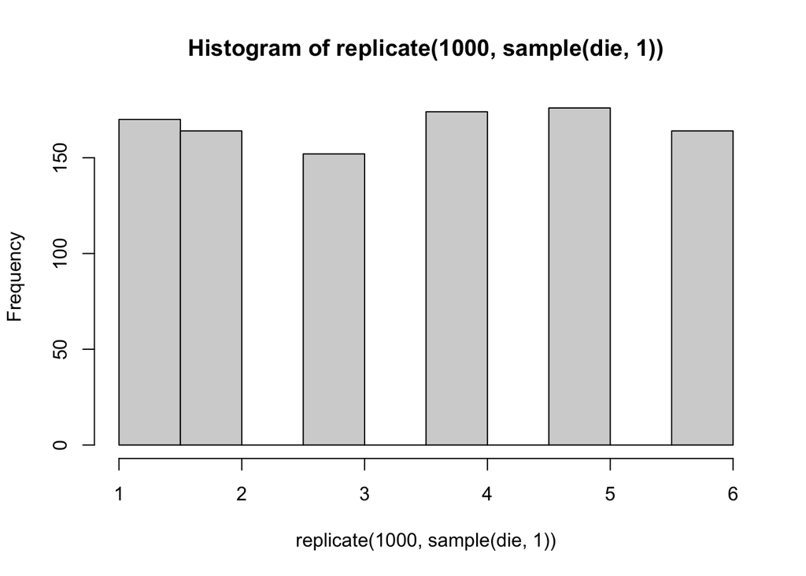

```r
set.seed(1)
replicate(1000, sample(die,1)) |> hist() #roll 1 die and repeat 1000 times
```

```r
mean(replicate(1000, sample(die,1))) #gives mean of 3.48
```

```
## [1] 3.48
```

2. A 1000 draws of a die which lands on 6 for 50% of the time.

I will start by making a weighted die with probabilities for each value inclusive of 1 through 6.

```r
weighted_die <- 1:6
prob = c(".1", ".1",".1",".1", ".1", ".5")
```

Next I will roll weighted_die 1000 times and create a histogram.

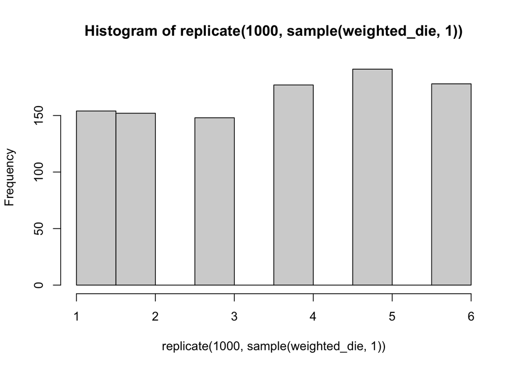

```r
set.seed(2)
replicate(1000, sample(weighted_die,1)) |> hist() #roll 1 weighted die and repeat 1000 times
```

```r
mean(replicate(1000, sample(weighted_die,1))) #gives mean of 3.441
```

```
## [1] 3.441
```

3. For C, I will repeat the steps in B with different probabilities.

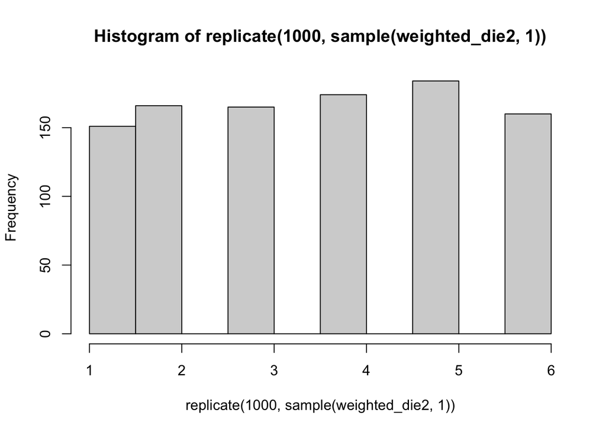

```r
weighted_die2 <- 1:6
prob = c("(1/6)", "(1/6)","(1/6)","(1/6)", "(1/3)", "(1/3)")

set.seed(4)
replicate(1000,sample(weighted_die2,1)) |> hist()
```

```r
mean(replicate(1000,sample(weighted_die2))) #calculating mean
```

```
## [1] 3.5
```

## Citation

Used the following link to think about question 3: https://math.stackexchange.com/questions/3670963/probability-calculating-the-probability-of-choosing-5-cards-with-4-different-s